# Human Activity Recognition

Charmaine Tressler

April 6, 2019

## Human Activity Recognition

### Introduction

Devices such as Jawbone Up, Nike FuelBand and Fitbit allow users to collect a large amount of data about personal activity.

In this study data has been collected from 6 young male participants who were asked to perform one set of ten repetitions of the Unilateral Dumbbell Biceps Curl correct and incorrectly in 5 different ways. The data is received from acceleromteres on the belt, forearm, arm and dumbell of each individual.

The following 5 classes were used:

Class A - exactly according to specification (correct) Class B - throwing the elbows to the front Class C - lifting the dumbbell only half way Class D - lowering dumbbell only half way Class E - throwing the hips to the front

The goal of this exercise is to predict the manner in which the exercise was done which is represented by the ‘classe’ variable in the dataset.

### Loading Packages

```r
library(caret)
```

```r
library(corrplot)
library(randomForest)
library(e1071)
library(gbm)
```

### Loading the provided Training data and splitting further into Test and Training data

```r
training <- read.csv(file = "https://d396qusza40orc.cloudfront.net/predmachlearn/pml-training.csv", header = TRUE)
train_data <- createDataPartition(training$classe, p=0.7, list = FALSE)
inTrain <- training[train_data,]
inTest <- training[-train_data,]
```

### PreProcessing Training data

Removing columns that have a value of primarily NA:

```r
training_rmna <- inTrain[,apply(inTrain, 2, function(x) !any(is.na(x)))]
```

Checking for highly correlated variables. Subsetting to only include numerical columns and removing first 4 columns.

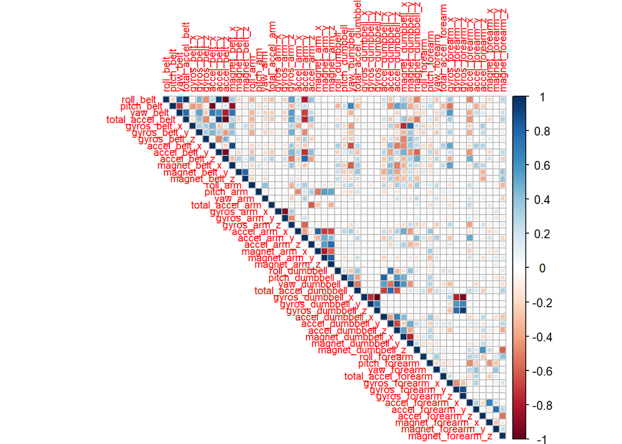

```r
nums <- training_rmna[, sapply(training_rmna, is.numeric)]
training_data = nums[, -c(1:4)]
corrplot(cor(training_data), method="square", type = "upper", tl.cex=0.7)
```

```r
df <- cor(training_data)

# Get colummns with high correlation (0ver 0.9) that are to be removed.
hc <- findCorrelation(df, cutoff=0.9)

# Remove these columns from the final dataset.
training_data_new = training_data[,-c(hc)]

# Add classe column to this dataset
training_data_new = cbind(training_data_new,classe=inTrain$classe)
```

Removing predictors with near zero variance:

```r
nzv <- nearZeroVar(training_data_new, uniqueCut = 20)
training_data_new <- training_data_new[,-c(nzv)]
```

### Train data using Random Forest and Gradient Boosting Model

We will now train this data using Random Forest with Cross Validation.

For cross validation, the method that was used was 5-fold cross validation with 2 repeats.

```r
control <- trainControl(method="repeatedcv", number=5, repeats = 2)
rf_model <- train(classe ~., data = training_data_new, method = "rf", trControl = control)
```

Out of bag estimate of error rate for random forest with 5-fold cross validation:

```r
rf_model$finalModel
```

```
##
## Call:
##  randomForest(x = x, y = y, mtry = param$mtry)
##                Type of random forest: classification
##                      Number of trees: 500
## No. of variables tried at each split: 22
##
##         OOB estimate of  error rate: 0.58%
## Confusion matrix:
##      A    B    C    D    E class.error
## A 3895    3    2    4    2 0.002816180
## B   12 2639    7    0    0 0.007148232
## C    0   15 2376    5    0 0.008347245
## D    0    0   18 2232    2 0.008880995
## E    0    0    4    6 2515 0.003960396
```

We will now train this data using Gradient Boosting Model with 5-fold cross validation repeated 2 times

```r
boost_model <- train(classe~., data = training_data_new, method ="gbm", trControl=control, verbose = FALSE)
```

Accuracy for Boosted model with 5 fold cross validation:

```r
boost_model
```

```
## Stochastic Gradient Boosting
##
## 13737 samples
##    42 predictor
##     5 classes: 'A', 'B', 'C', 'D', 'E'
##
## No pre-processing
## Resampling: Cross-Validated (5 fold, repeated 2 times)
## Summary of sample sizes: 10990, 10990, 10991, 10988, 10989, 10991, ...
## Resampling results across tuning parameters:
##
##   interaction.depth  n.trees  Accuracy   Kappa
##   1                   50      0.7153670  0.6371871
##   1                  100      0.7966448  0.7418900
##   1                  150      0.8366821  0.7929839
##   2                   50      0.8448710  0.8031701
##   2                  100      0.8995405  0.8727875
##   2                  150      0.9218892  0.9011215
##   3                   50      0.8883298  0.8584943
##   3                  100      0.9337915  0.9162005
##   3                  150      0.9553756  0.9435444
##
## Tuning parameter 'shrinkage' was held constant at a value of 0.1
##
## Tuning parameter 'n.minobsinnode' was held constant at a value of 10
## Accuracy was used to select the optimal model using the largest value.
## The final values used for the model were n.trees = 150,
##  interaction.depth = 3, shrinkage = 0.1 and n.minobsinnode = 10.
```

### Prediction on training data

1. Using random forest with 5-fold cross validation

```r
rf_model_predict_intrain <- predict(rf_model, training_data_new)
confusionMatrix(rf_model_predict_intrain, training_data_new$classe)
```

```
## Confusion Matrix and Statistics
##
##           Reference
## Prediction    A    B    C    D    E
##          A 3906    0    0    0    0
##          B    0 2658    0    0    0
##          C    0    0 2396    0    0
##          D    0    0    0 2252    0
##          E    0    0    0    0 2525
##
## Overall Statistics
##
##                Accuracy : 1
##                  95% CI : (0.9997, 1)
##     No Information Rate : 0.2843
##     P-Value [Acc > NIR] : < 2.2e-16
##
##                   Kappa : 1
##
##  Mcnemar's Test P-Value : NA
##
## Statistics by Class:
##
##                      Class: A Class: B Class: C Class: D Class: E
## Sensitivity            1.0000   1.0000   1.0000   1.0000   1.0000
## Specificity            1.0000   1.0000   1.0000   1.0000   1.0000
## Pos Pred Value         1.0000   1.0000   1.0000   1.0000   1.0000
## Neg Pred Value         1.0000   1.0000   1.0000   1.0000   1.0000
## Prevalence             0.2843   0.1935   0.1744   0.1639   0.1838
## Detection Rate         0.2843   0.1935   0.1744   0.1639   0.1838
## Detection Prevalence   0.2843   0.1935   0.1744   0.1639   0.1838
## Balanced Accuracy      1.0000   1.0000   1.0000   1.0000   1.0000
```

2. Using gradient boosting model with 5-fold cross validation

```r
boost_model_predict_intrain <- predict(boost_model, training_data_new)
confusionMatrix(boost_model_predict_intrain, training_data_new$classe)
```

```
## Confusion Matrix and Statistics
##
##           Reference
## Prediction    A    B    C    D    E
##          A 3864   61    2    5    6
##          B   22 2530   55    5   21
##          C   13   59 2306   63   13
##          D    3    4   30 2166   24
##          E    4    4    3   13 2461
##
## Overall Statistics
##
##                Accuracy : 0.9702
##                  95% CI : (0.9672, 0.9729)
##     No Information Rate : 0.2843
##     P-Value [Acc > NIR] : < 2.2e-16
##
##                   Kappa : 0.9622
##
##  Mcnemar's Test P-Value : 3.134e-09
##
## Statistics by Class:
##
##                      Class: A Class: B Class: C Class: D Class: E
## Sensitivity            0.9892   0.9518   0.9624   0.9618   0.9747
## Specificity            0.9925   0.9907   0.9870   0.9947   0.9979
## Pos Pred Value         0.9812   0.9609   0.9397   0.9726   0.9903
## Neg Pred Value         0.9957   0.9885   0.9920   0.9925   0.9943
## Prevalence             0.2843   0.1935   0.1744   0.1639   0.1838
## Detection Rate         0.2813   0.1842   0.1679   0.1577   0.1792
## Detection Prevalence   0.2867   0.1917   0.1786   0.1621   0.1809
## Balanced Accuracy      0.9909   0.9713   0.9747   0.9783   0.9863
```

### Prediction on Test data

1. Using random forest with 5-fold cross validation

```r
rf_model_predict_intest <- predict(rf_model, inTest)
confusionMatrix(rf_model_predict_intest, inTest$classe)
```

```
## Confusion Matrix and Statistics
##
##           Reference
## Prediction    A    B    C    D    E
##          A 1673   11    0    0    0
##          B    0 1125    4    0    0
##          C    1    1 1021    8    3
##          D    0    0    1  955    6
##          E    0    2    0    1 1073
##
## Overall Statistics
##
##                Accuracy : 0.9935
##                  95% CI : (0.9911, 0.9954)
##     No Information Rate : 0.2845
##     P-Value [Acc > NIR] : < 2.2e-16
##
##                   Kappa : 0.9918
##
##  Mcnemar's Test P-Value : NA
##
## Statistics by Class:
##
##                      Class: A Class: B Class: C Class: D Class: E
## Sensitivity            0.9994   0.9877   0.9951   0.9907   0.9917
## Specificity            0.9974   0.9992   0.9973   0.9986   0.9994
## Pos Pred Value         0.9935   0.9965   0.9874   0.9927   0.9972
## Neg Pred Value         0.9998   0.9971   0.9990   0.9982   0.9981
## Prevalence             0.2845   0.1935   0.1743   0.1638   0.1839
## Detection Rate         0.2843   0.1912   0.1735   0.1623   0.1823
## Detection Prevalence   0.2862   0.1918   0.1757   0.1635   0.1828
## Balanced Accuracy      0.9984   0.9934   0.9962   0.9946   0.9955
```

2. Using gradient boosting model with 5-fold cross validation

```r
boost_model_predict_intest <- predict(boost_model, inTest)
confusionMatrix(boost_model_predict_intest, inTest$classe)
```

```
## Confusion Matrix and Statistics
##
##           Reference
## Prediction    A    B    C    D    E
##          A 1640   41    1    2    1
##          B   20 1066   33    2    5
##          C   10   25  968   29    9
##          D    1    2   23  928   18
##          E    3    5    1    3 1049
##
## Overall Statistics
##
##                Accuracy : 0.9602
##                  95% CI : (0.9549, 0.9651)
##     No Information Rate : 0.2845
##     P-Value [Acc > NIR] : < 2.2e-16
##
##                   Kappa : 0.9497
##
##  Mcnemar's Test P-Value : 0.0001331
##
## Statistics by Class:
##
##                      Class: A Class: B Class: C Class: D Class: E
## Sensitivity            0.9797   0.9359   0.9435   0.9627   0.9695
## Specificity            0.9893   0.9874   0.9850   0.9911   0.9975
## Pos Pred Value         0.9733   0.9467   0.9299   0.9547   0.9887
## Neg Pred Value         0.9919   0.9847   0.9880   0.9927   0.9932
## Prevalence             0.2845   0.1935   0.1743   0.1638   0.1839
## Detection Rate         0.2787   0.1811   0.1645   0.1577   0.1782
## Detection Prevalence   0.2863   0.1913   0.1769   0.1652   0.1803
## Balanced Accuracy      0.9845   0.9616   0.9642   0.9769   0.9835
```

The Random Forest Model has better prediction accuracy so we will use that for predicting the classe in the test data.

### Loading provided Test data to predict outcome

```r
Testing <- read.csv(file = "https://d396qusza40orc.cloudfront.net/predmachlearn/pml-testing.csv", header=TRUE)
predict_rf_testing <- predict(rf_model, Testing)
predict_rf_testing
```

```
##  [1] B A B A A E D B A A B C B A E E A B B B
## Levels: A B C D E
```

## Citation

Velloso,E.; Bulling, A.; Gellersen, H.; Ugulino, W.; Fuks, H. QualitativeActivity Recognition of Weight Lifting Exercises. Proceedings of4th International Conference in Cooperation with SIGCHI (AugmentedHuman ’13) . Stuttgart, Germany: ACM SIGCHI, 2013.

Read more: http://web.archive.org/web/20161224072740/http:/groupware.les.inf.puc-rio.br/har#weight_lifting_exercises#ixzz5kKOUfure